# 14. Permutation test

Lorenzo Bertola

Document last run on 2022-04-18

## 1. Background

Now that we have identified sex-linked markers based on patterns of heterozygosity and homozygosity, let’s assess how robust our results are by conducting permutation tests, similarly to how Jeffries et al. (2019) did.

## 2. Permutation test for number of identified sex linked loci

I will now perform a permutation test, assigning sex at random in the same 50:50 proportion, and assess whether the number of identified sex linked markers is significantly different.

### 2.1. Running the permutations on the University HPC

Because I am running 10.000 iterations, thus resulting in large lists (~50 Gb), I do so on the university High Performance Computing cluster. To achieve this, I wrote 2 scripts. An R scripts *3_3_PermutationTestOfSexLinkedLoci.R* and a shell script for submitting the R job *3_3_PermutationTest.sh*.

The former looks like this:

```r
## Set working directory
setwd("~/jc274669/ProjectDirectory/3_SexLinked/")

## Load Required packages
library(tidyverse)

## Permutation test for number of identified sex linked loci

#read input data
my.df <- read_delim(file = "./13_2_InputDataframe_sex.txt",
                    delim = "\t")

#Now we want to create 10000 subsets of 2 random groups of 19 individuals each.

###############################################################
#create empty list of desired length
my.list <- vector("list",10000)

#iterate over 1:10000
for (i in seq(1,10000,1)){
  #set seed
  set.seed(i)

  #sample 19 random numbers between 2 and 39
  positions <- sample(2:39,19,replace = FALSE)

  #subset dataframe according to random indices
  LS_1 <- my.df %>% select(markerID, all_of(positions))
  LS_2 <- my.df %>% select(-all_of(positions))

  #join two subsets into one list
  my.list.b <- list(LS_1,LS_2)

  #name the list elements
  names(my.list.b) <- c("LS_1","LS_2")

  #assign list to empty outer list element
  my.list[[i]] <- my.list.b
}

rm(LS_1,LS_2,my.list.b,positions)
###############################################################

#Now we calculate number of homozygotes, heterozygotes and missing data, as well as proportions of these, and proportion of the 2 alleles for all 100 random subsets

###############################################################
#create empty list of desired length
my.met <- vector("list",10000)

#iterate over numbers from 1 to 10000
for (i in seq(1,10000,1)){

  #apply calculations to both list elements
  #these represent the two 'sexes'
  my.met.2 <- lapply(my.list[[i]], function(x){

    markerID <- x %>% select(markerID)
    tempx <- x %>% select(-markerID)

    Zero <- rowSums(tempx==0)
    One <- rowSums(tempx==1) # heterozygote
    Two <- rowSums(tempx==2) # snp homozygote
    Mis <- rowSums(tempx== -1) #missing data

    y <- as_tibble(cbind(markerID,Zero,One,Two,Mis))

    y <- y %>% mutate(
    HomRef = Zero/(Zero+One+Two),
    Het = One/(Zero+One+Two),
    HomSnp = Two/(Zero+One+Two),
    pMis = Mis/(Zero+One+Two+Mis),
    Ref = ((2*Zero) + One)/(2*(Zero+One+Two)),
    Snp = ((2*Two) + One)/(2*(Zero+One+Two))
    )

    return(y)
  })

  #join two 'sexes' by marker ID
  my.met.2 <- full_join(my.met.2$LS_1, my.met.2$LS_2,
                by="markerID", suffix = c("_1","_2"))

  #assign resulting dataframe to outer list empty element
  my.met[[i]] <- my.met.2
}

rm(my.met.2,i)
###############################################################

#Now for each of the methods that we want to assess (Method 1, Method 2, Method 5) we will calculate how many sex linked markers would be identified and build a distribution from it, and then compare whether that's significantly different from the number we identified.


###############################################################
### Method 1 ###

perm_M1 <- lapply(my.met, function(x){
  y <- x %>%
    filter(Ref_1 > 0.9 & Ref_2 > 0.4 & Ref_2 < 0.6) %>%
    nrow()

  return(y)
})

perm_M1 <- unlist(perm_M1)

### Method 2 ###

perm_M2 <- lapply(my.met, function(x){
  y <- x %>%
    filter(HomRef_2==1 & Het_1 >= 0.5) %>%
    nrow()

  return(y)
})

perm_M2 <- unlist(perm_M2)

### Method 5 ###

perm_M5 <- lapply(my.met, function(x){
  y <- x %>%
    filter(Het_1 > 0.55 &
             HomSnp_2 == 0 &
             Het_2 < 0.2 &
             HomRef_2 > 0.8) %>%
    nrow()

  return(y)
})

perm_M5 <- unlist(perm_M5)

#Save the resulting files

perm.results <- list(perm_M1, perm_M2, perm_M5)
saveRDS(perm.results, file = "./14_1_PermTest_Results.RData")
```

While the latter contains the following

```bash
#!/bin/bash-403

#PBS -N permTest
#PBS -l ncpus=1
#PBS -l mem=200g
#PBS -l walltime=24:00:00

#load R 4.0.3
module load anaconda3
source $CONDA_PROF/conda.sh
conda activate R-4.0.3

#set directory
cd ~/ProjectDirectory/3_SexLinked/

#run R script
R -f ./0_rscripts/3_3_PermutationTestOfSexLinkedLoci.R

#close conda environment
conda deactivate
```

### 2.2. Plotting the results

Once the script is done running, I can read in the input file.

```r
library(tidyverse)
perm.results <- readRDS("../3_SexLinked/14_1_PermTest_Results.RData")

names(perm.results) <- c("M1","M2","M5")
```

```r
perm.results <- lapply(perm.results, function(x){
  y <- tibble(rep=seq(1,10000,1), markers=x)
})

M1 <- perm.results$M1 %>% add_column(method="M1")
M2 <- perm.results$M2 %>% add_column(method="M2")
M5 <- perm.results$M5 %>% add_column(method="M5")

perm.results <- rbind(M1, M2, M5)
```

Now, let’s calculate the 95th and 99th percentile for these estimates, and see whether the number of markers we identified with the correct sex assignments is above that.

```r
perm.results %>%
  group_by(method) %>%
  summarise(q95=quantile(markers,0.95),
            q99=quantile(markers,0.99))
```

```
## # A tibble: 3 × 3
##   method   q95   q99
##   <chr>  <dbl> <dbl>
## 1 M1        47    73
## 2 M2        20    31
## 3 M5        18    24
```

```r
sexlinked <- tibble(method=c("M1","M1","M2","M2","M5","M5"),
                    sexdet=c("XY","ZW","XY","ZW","XY","ZW"),
                    markers=c(4,1,10,0,25,1))

#signif <- tibble(method=c("M1"),
#                 markers=c(45))
```

Plot distribution of permutated estimates as violin plots, and plot estimate from true sex-assignment as coloured dots (blue for XY and red for ZW).

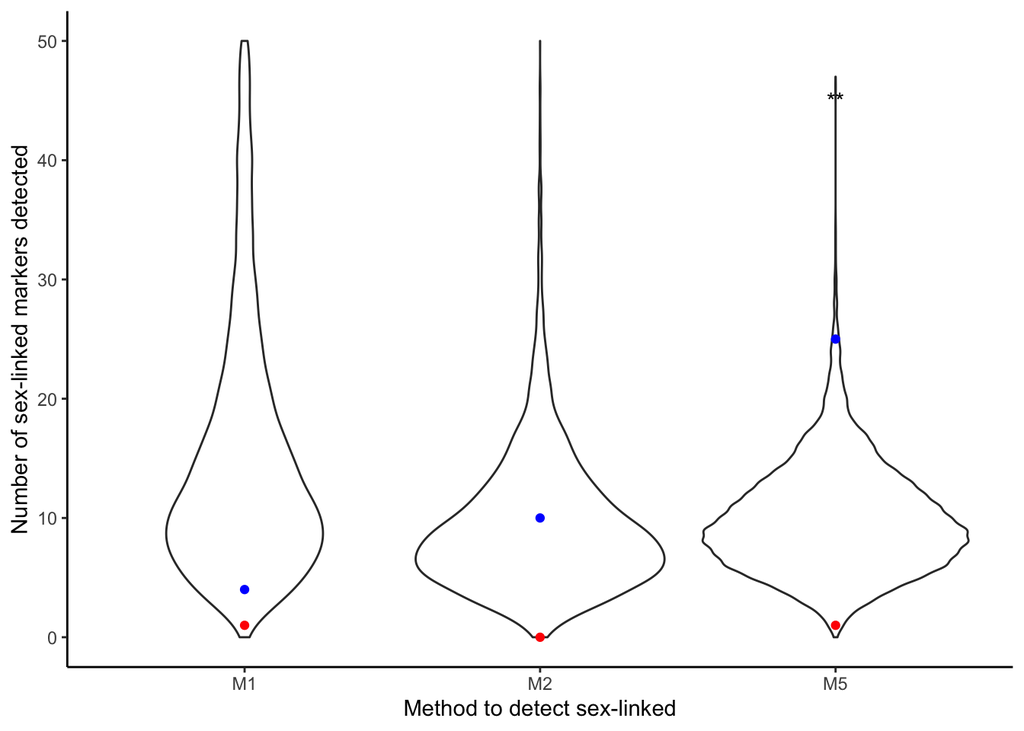

```r
p1 <- ggplot() +
  geom_violin(data=perm.results,
              aes(y=markers,x=method)) +
  geom_point(data=sexlinked,
             aes(y=markers,x=method,
                 fill=sexdet,color=sexdet)) +
  geom_text(aes(x="M5",y=as.double(45)),label="**") +
  scale_color_manual(values = c("XY" = "blue", "ZW" = "red")) +
  ylab("Number of sex-linked markers detected") +
  xlab("Method to detect sex-linked") +
  scale_y_continuous(limits = c(0,50)) +
  theme_classic() +
  theme(legend.position = "none")

p1
```

Only Method 5 (Lambert et al., 2016) found more XY linked markers than the 99th percentile of permuted estimates.

Save the resulting figure

```r
ggsave(filename = "../3_SexLinked/14_2_PermTest_Plot.jpg",
       plot=p1,
       device = "jpeg",
       width = 7, height = 4,
       dpi = 300)
```

Let’s look at method 5 in detail, this time as a frequency plot.

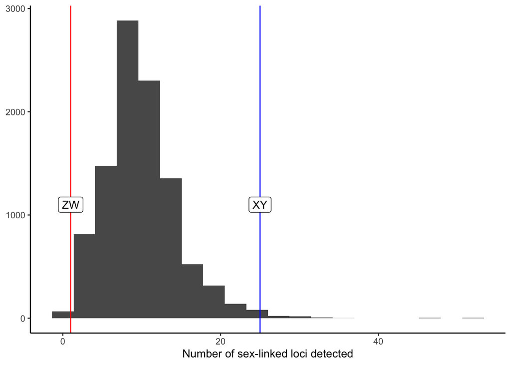

```r
markers <- tibble(x=c(1,25),
                  y=c(1100,1100),
                  label=c("ZW","XY"))

p2 <- ggplot(M5) +
  geom_histogram(aes(x=markers), bins = 20) +
  geom_vline(aes(xintercept=1), colour="red") +
  geom_vline(aes(xintercept=25), colour="blue") +
  geom_label(data=markers, aes(x=x,y=y,label=label)) +
  xlab("Number of sex-linked loci detected") +
  theme_classic() +
  theme(axis.title.y = element_blank())

p2
```

```r
ggsave(filename = "../3_SexLinked/14_3_PermTest_HistM5.jpg",
       plot=p2,
       device = "jpeg",
       width = 7, height = 4,
       dpi = 300)
```